# DiceSim - Beat Statistics

Daniel

2022-04-04

# Overview

Dice rolls can be trickier than they seem!

When you roll a bunch of dice, you might first think that any sequence you get is equally likely. After all, each roll is independent and with a probability of 1/6.

But, say you roll two dice, there are 36 possibilities, one of which is (6, 6). But, for example, getting a five and a six can occur in two ways: (5, 6) or (6, 5).

For a fair die we expect the average distribution to be even. DiceSim lets you roll dice and see how likely your result is, how uneven your distribution is.

# How to Use

- The instructions are in the app. Just select the amount of dice and then click roll, and observe the result!

# Example (1)

Say we roll 10,000 dice and check a histogram. It’s fairly even, and it would be difficult to get say, all sixes.

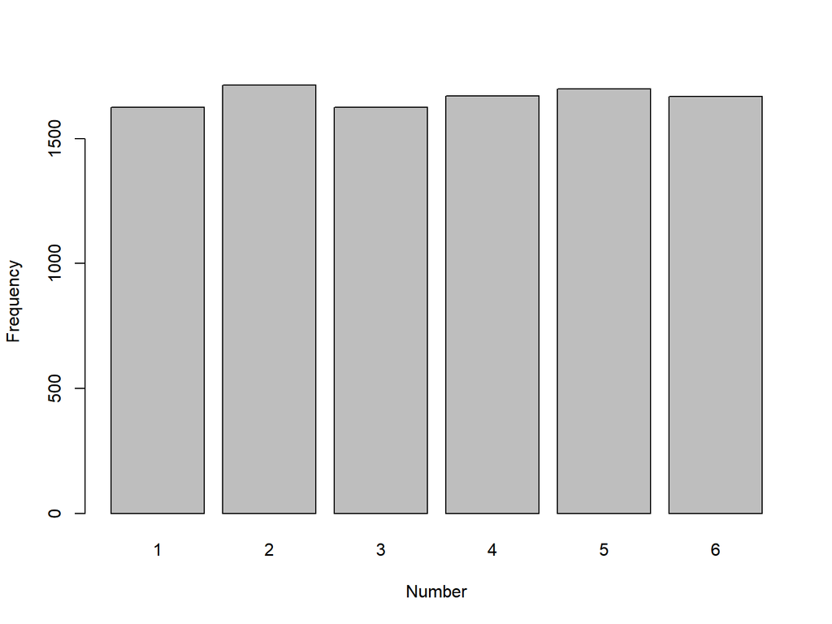

```r
result = sample(1:6,10000,replace=T)
barplot(table(result), xlab="Number", ylab="Frequency")
```

# Example (2)

Now say we roll 100 dice. This is a smaller sample, so it’s “easier” to get an uneven distribution.

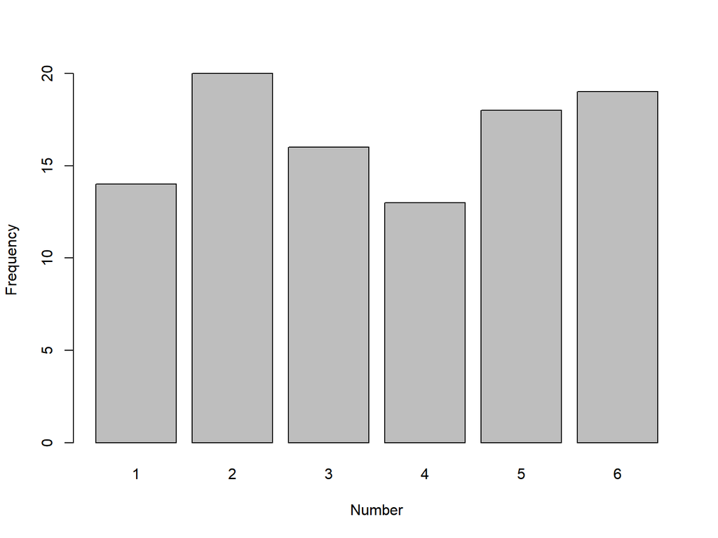

```r
result = sample(1:6,100,replace=T)
barplot(table(result), xlab="Number", ylab="Frequency")
```